# Data 606 - Feature Engineering Plots

February 8th, 2020

## 3. Data Cleaning and Imputation

```r
library(survey)
library(sampling)
library(tidyverse)
library(mosaic)
library(kableExtra)
library(mice)
library(cowplot)
```

Now we can look at just the features that have missing values and impute the data that we need for future analysis.

```r
count_na = function(df) {
  x = df %>%
    summarise_all(funs(sum(is.na(.)))) %>%
    gather(key = "Feature", value = "NAs") %>%
    filter(NAs > 0)
  return(x)
}
count_na(house.orig)
```

| Feature | NAs |
| --- | --- |
| LotFrontage | 259 |
| Alley | 1369 |
| MasVnrType | 8 |
| MasVnrArea | 8 |
| BsmtQual | 37 |
| BsmtCond | 37 |
| BsmtExposure | 38 |
| BsmtFinType1 | 37 |
| BsmtFinType2 | 38 |
| Electrical | 1 |

[output cut: 9 more lines]

From the description of the data set we know that for a number of these features “NA” is actually a true category that we can simply fill in.

```r
replacements = list(Alley = "NoAlley",
                    BsmtCond = "NoBase",
                    BsmtQual = "NoBase",
                    BsmtExposure = "NoBase",
                    BsmtFinType1 = "NoBase",
                    BsmtFinType2 = "NoBase",
                    FireplaceQu = "NoFirePlace",
                    GarageType = "NoGarage",
                    GarageYrBlt = "NoGarage",
                    GarageFinish = "NoGarage",
                    GarageQual = "NoGarage",
                    GarageCond = "NoGarage",
                    PoolQC =  "NoPool",
                    Fence = "NoFence"
                    )
house.clean = house.orig %>% replace_na(replacements)
count_na(house.clean)
```

| Feature | NAs |
| --- | --- |
| LotFrontage | 259 |
| MasVnrType | 8 |
| MasVnrArea | 8 |
| Electrical | 1 |
| MiscFeature | 1406 |

We are left with 5 features that we need to explore further.

`MiscFeature` is missing 96.3% of the values, and upon reviewing the description of this category we have deemed it safe to simply remove this feature.

| Var1 | Freq |
| --- | --- |
| FuseA | 94 |
| FuseF | 27 |
| FuseP | 3 |
| Mix | 1 |
| SBrkr | 1335 |

For `Electrical` we see that one of the categories completey dominates the other categories and we have decided to choose the dominant category to impute into the one missing value.

```r
house.clean = house.clean %>%
  select(-MiscFeature) %>%
  mutate(Electrical = replace(Electrical, is.na(Electrical), 'SBrkr'))
count_na(house.clean)
```

| Feature | NAs |
| --- | --- |
| LotFrontage | 259 |
| MasVnrType | 8 |
| MasVnrArea | 8 |

We can look `MasVnrType` in a bit more detail and see if there is an obvious way to impute these 8 missing values.

```r
table(house.clean$MasVnrType)
```

```
 BrkCmn BrkFace    None   Stone
     15     445     864     128
```

From the above table there is no clear way to grab values from these, but maybe we can stratify sample 8 and impute these randomly.

| MasVnrType |
| --- |
| None |
| None |
| Stone |
| None |
| BrkFace |
| Stone |
| Stone |
| BrkFace |

```r
tempData <- mice(house.impute, m=5, maxit=5, meth='pmm', seed=500)
```

```
 * Please inspect the loggedEvents
```

```
Number of logged events: 143
```

```r
tempComplete = complete(tempData, 1)
house.impute = house.impute %>% mutate(MasVnrArea = tempComplete$MasVnrArea,
                                       LotFrontage = tempComplete$LotFrontage)
count_na(house.impute)
```

| Feature | NAs |
| --- | --- |

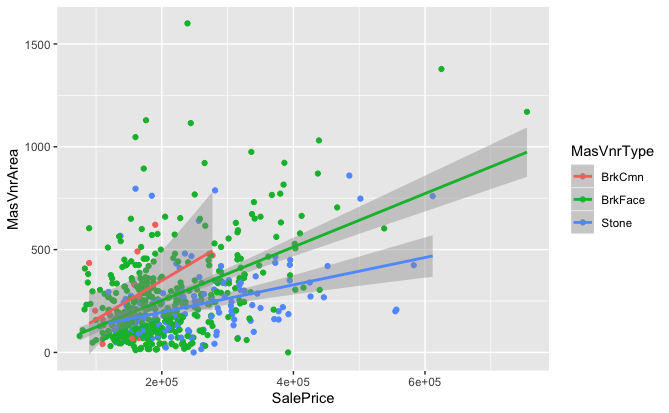

```r
ggplot(house.clean %>% filter(MasVnrType != 'None'), aes(y = MasVnrArea, x = SalePrice, color = MasVnrType)) +
  geom_point() +
  geom_smooth(method = 'lm')
```

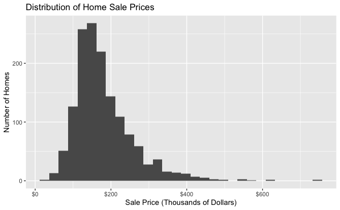

```r
house.clean %>%
  ggplot(aes(x = SalePrice / 1000)) +
  geom_histogram() +
  xlab("Sale Price (Thousands of Dollars)") +
  ylab("Number of Homes") +
  scale_x_continuous(labels = scales::dollar) +
  ggtitle("Distribution of Home Sale Prices")
```

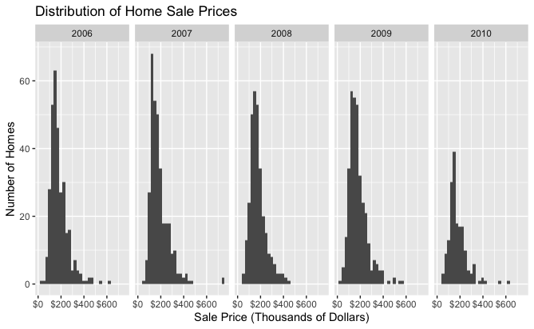

```r
house.clean %>%
  group_by(YrSold) %>%
  ggplot(aes(x = SalePrice / 1000)) +
  geom_histogram() +
  facet_grid(~YrSold) +
  xlab("Sale Price (Thousands of Dollars)") +
  ylab("Number of Homes") +
  scale_x_continuous(labels = scales::dollar) +
  ggtitle("Distribution of Home Sale Prices")
```

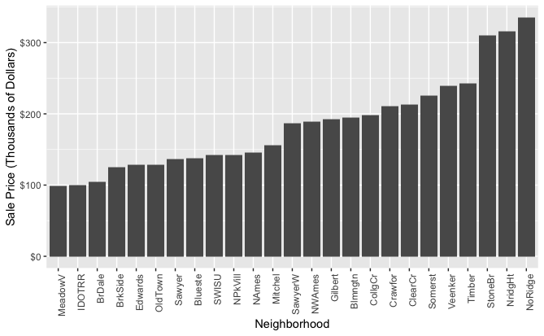

```r
house.clean %>%
  group_by(Neighborhood) %>%
  summarise(SalePriceAvg = mean(SalePrice)) %>%
  arrange(SalePriceAvg) %>%
  ggplot(aes(x = reorder(Neighborhood, SalePriceAvg), y = SalePriceAvg / 1000)) +
  geom_col() +
  theme(axis.text.x = element_text(angle = 90, hjust = 1)) +
  ylab("Sale Price (Thousands of Dollars)") +
  xlab("Neighborhood") +
  scale_y_continuous(labels = scales::dollar)
```

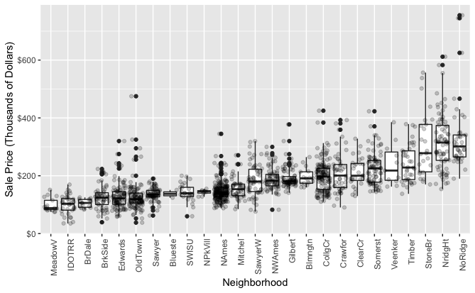

```r
house.clean %>%
  ggplot(aes(x = reorder(Neighborhood, SalePrice), y = SalePrice / 1000)) +
  geom_boxplot() +
  theme(axis.text.x = element_text(angle = 90, hjust = 1)) +
  ylab("Sale Price (Thousands of Dollars)") +
  xlab("Neighborhood") +
  scale_y_continuous(labels = scales::dollar) +
  geom_point(position = 'jitter', alpha = 0.2)
```

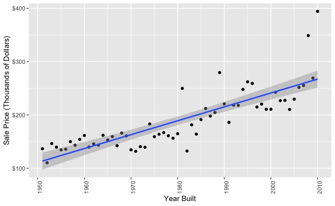

```r
house.clean %>%
  group_by(YearBuilt) %>%
  summarise(SalePriceAvg = mean(SalePrice)) %>%
  filter(!(YearBuilt < 1900 & SalePriceAvg > 250)) %>% # Important to note
  filter(YearBuilt > 1950) %>%
  arrange(SalePriceAvg) %>%
  ggplot(aes(x = YearBuilt, y = SalePriceAvg / 1000)) +
  geom_point() +
  theme(axis.text.x = element_text(angle = 90, hjust = 1)) +
  ylab("Sale Price (Thousands of Dollars)") +
  xlab("Year Built") +
  scale_y_continuous(labels = scales::dollar) +
  geom_smooth(method = 'lm')
```

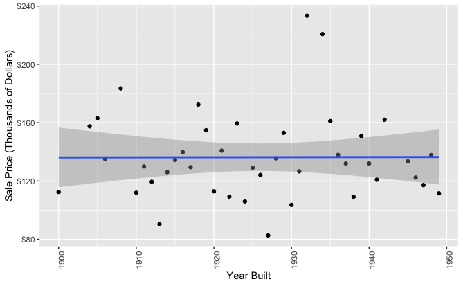

```r
house.clean %>%
  group_by(YearBuilt) %>%
  summarise(SalePriceAvg = mean(SalePrice)) %>%
  filter(!(YearBuilt < 1900 & SalePriceAvg > 250)) %>% # Important to note
  filter(YearBuilt < 1950) %>%
  arrange(SalePriceAvg) %>%
  ggplot(aes(x = YearBuilt, y = SalePriceAvg / 1000)) +
  geom_point() +
  theme(axis.text.x = element_text(angle = 90, hjust = 1)) +
  ylab("Sale Price (Thousands of Dollars)") +
  xlab("Year Built") +
  scale_y_continuous(labels = scales::dollar) +
  geom_smooth(method = 'lm')
```

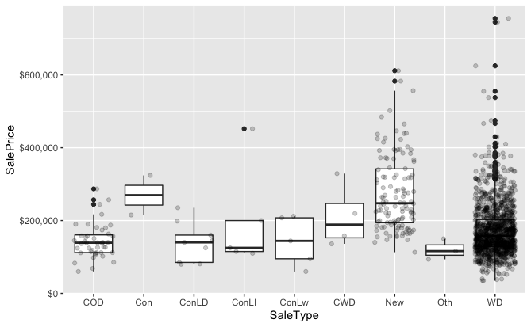

```r
house.clean %>%
  ggplot(aes(x = SaleType, y = SalePrice)) +
  scale_y_continuous(labels = scales::dollar) +
  geom_boxplot() +
  geom_point(position = 'jitter', alpha = 0.2)
```

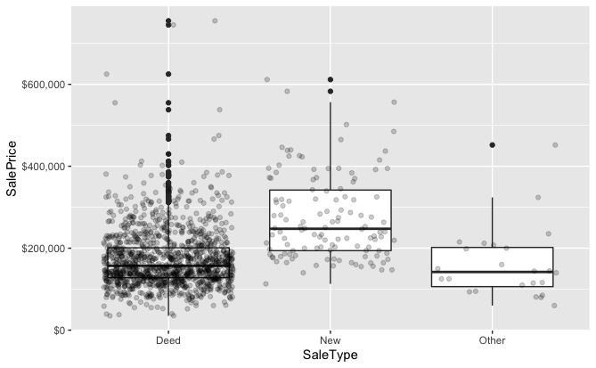

```r
house.clean %>%
  mutate(SaleType = ifelse(SaleType == 'New',
                     "New",
                     ifelse(SaleType %in% c("WD", "CWD", "VWD", "COD"),
                            "Deed",
                            "Other"))) %>%
  ggplot(aes(x = SaleType, y = SalePrice)) +
  scale_y_continuous(labels = scales::dollar) +
  geom_boxplot() +
  geom_point(position = 'jitter', alpha = 0.2)
```

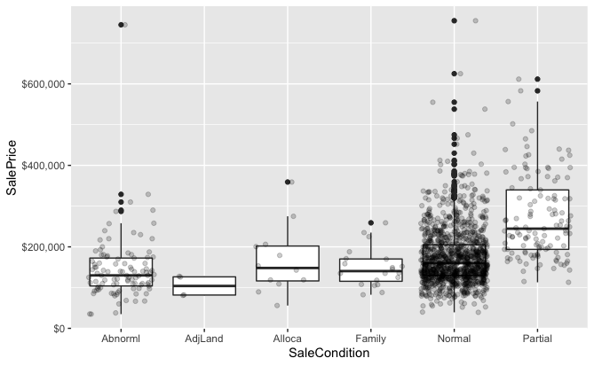

```r
house.clean %>%
  ggplot(aes(x = SaleCondition, y = SalePrice)) +
  geom_boxplot() +
  geom_point(position = 'jitter', alpha = 0.2) +
  scale_y_continuous(labels = scales::dollar)
```

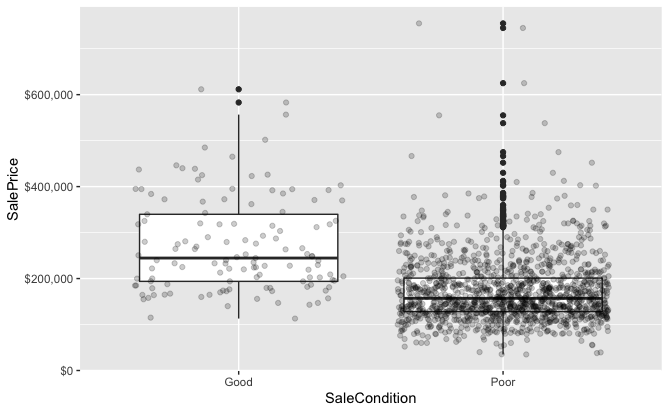

```r
house.clean %>%
  mutate(SaleCondition = ifelse(SaleCondition %in% c("Partial"),"Good", "Poor")) %>%
  ggplot(aes(x = SaleCondition, y = SalePrice)) +
  geom_boxplot() +
  geom_point(position = 'jitter', alpha = 0.2) +
  scale_y_continuous(labels = scales::dollar)
```

```r
OverallCond_hist <- house.clean %>%
  ggplot(aes(x = OverallCond)) +
  geom_bar()
OverallCond_box <- house.clean %>%
  ggplot(aes(y = SalePrice, x = OverallCond)) +
  geom_boxplot()

plot_grid(OverallCond_hist, OverallCond_box, ncol = 1)
```

[figure not shown]

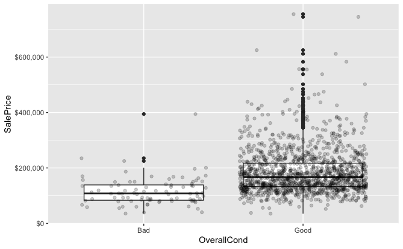

```r
house.clean %>%
  mutate(OverallCond = ifelse(OverallCond >= 5, "Good", "Bad")) %>%
  ggplot(aes(y = SalePrice, x = OverallCond)) +
  geom_boxplot() +
  geom_point(position = 'jitter', alpha = 0.2) +
  scale_y_continuous(labels = scales::dollar)
```

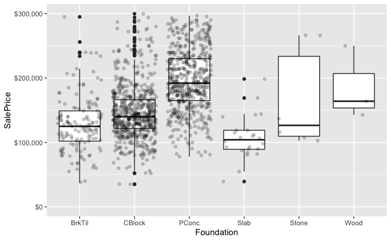

```r
house.clean %>%
  ggplot(aes(x = Foundation, y = SalePrice)) +
  stat_boxplot() +
  geom_point(position = 'jitter', alpha = 0.2) +
  scale_y_continuous(labels = scales::dollar, limits = c(0, 300000))
```

```r
house.clean %>%
  mutate(Foundation = ifelse(Foundation == "PConc", Foundation, "Other")) %>%
  ggplot(aes(x = Foundation, y = SalePrice)) +
  stat_boxplot() +
  geom_point(position = 'jitter', alpha = 0.2) +
  scale_y_continuous(labels = scales::dollar, limits = c(0, 300000))
```

[output not shown]

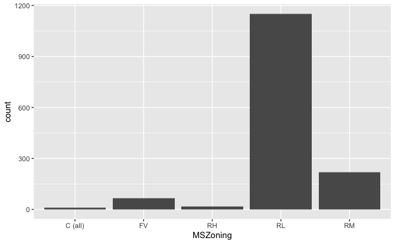

```r
house.clean %>%
  ggplot(aes(x = MSZoning)) +
  geom_bar()
```

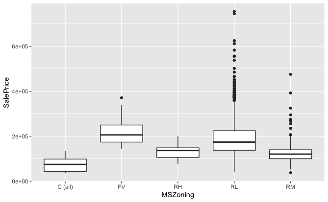

```r
house.clean %>%
  ggplot(aes(x = MSZoning, y = SalePrice)) +
  geom_boxplot()
```

[output not shown]

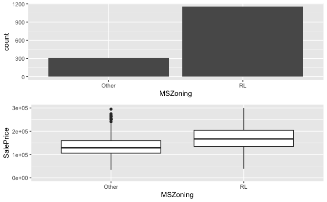

```r
MSZoning_hist <- house.clean %>%
  mutate(MSZoning = ifelse(MSZoning == "RL", MSZoning, "Other")) %>%
  ggplot(aes(x = MSZoning)) +
  geom_bar()
MSZoning_box <- house.clean %>%
  mutate(MSZoning = ifelse(MSZoning == "RL", MSZoning, "Other")) %>%
  ggplot(aes(x = MSZoning, y = SalePrice)) +
  geom_boxplot() +
  scale_y_continuous(limits = c(0, 300000))
plot_grid(MSZoning_hist, MSZoning_box, ncol = 1)
```

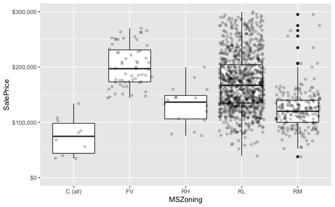

```r
house.clean %>%
  ggplot(aes(x = MSZoning, y = SalePrice)) +
  geom_boxplot() +
  geom_point(position = 'jitter', alpha = 0.2) +
  scale_y_continuous(labels = scales::dollar, limits = c(0, 300000))
```

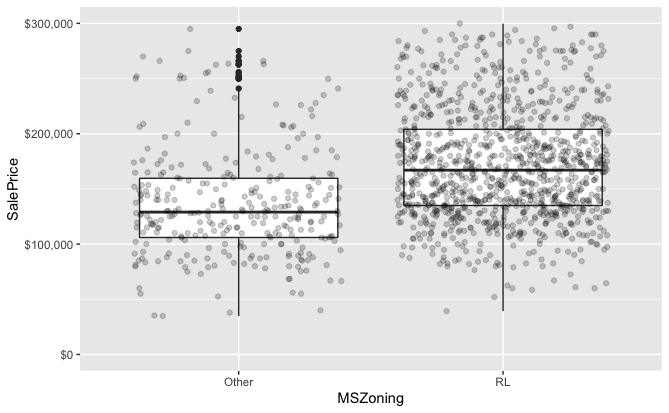

```r
house.clean %>%
  mutate(MSZoning = ifelse(MSZoning == "RL", MSZoning, "Other")) %>%
  ggplot(aes(x = MSZoning, y = SalePrice)) +
  geom_boxplot() +
  geom_point(position = 'jitter', alpha = 0.2) +
  scale_y_continuous(labels = scales::dollar, limits = c(0, 300000))
```

```r
house.clean %>%
  ggplot(aes(x = as.factor(MSSubClass), y = SalePrice)) +
  geom_boxplot() +
  geom_point(position = 'jitter', alpha = 0.2)
```

[output not shown]

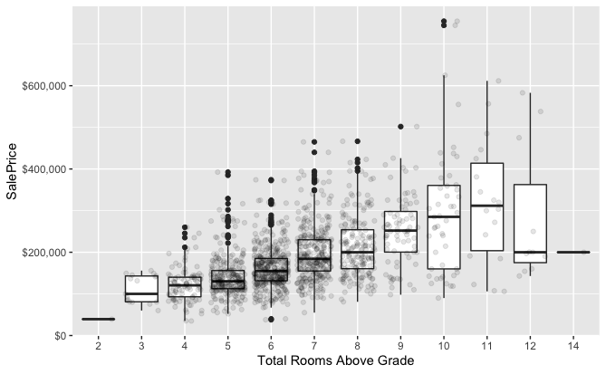

```r
house.clean %>%
  ggplot(aes(x = factor(TotRmsAbvGrd), y = SalePrice)) +
  geom_boxplot() +
  geom_point(position = 'jitter', alpha = 0.1) +
  scale_y_continuous(labels = scales::dollar) +
  xlab("Total Rooms Above Grade")
```

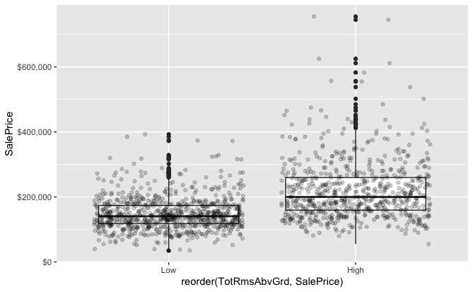

```r
house.clean %>%
  mutate(TotRmsAbvGrd = ifelse(TotRmsAbvGrd >= 7, "High", "Low")) %>%
  ggplot(aes(x = reorder(TotRmsAbvGrd, SalePrice), y = SalePrice)) +
  geom_boxplot() +
  geom_point(position = 'jitter', alpha = 0.2) +
  scale_y_continuous(labels = scales::dollar)
```

```r
# Remove this trash!!
house.clean %>%
  filter(PoolArea > 0) %>%
  ggplot(aes(x = PoolArea, y = SalePrice)) +
  geom_point() + geom_smooth(method = 'lm')

house.clean %>%
  mutate(Pool = PoolArea > 0) %>%
  ggplot(aes(x = Pool, y = SalePrice)) +
  geom_boxplot()

house.clean %>%
  group_by(Fence) %>%
  ggplot(aes(x = Fence, y = SalePrice)) +
  geom_boxplot() + geom_point(position = 'jitter', alpha = 0.2) + scale_y_continuous(labels = scales::dollar)

house.clean %>%
  filter(MiscVal > 0, MiscVal < 2500) %>%
  ggplot(aes(x = MiscVal, y = SalePrice)) +
  geom_point()

house.clean %>%
  group_by(Electrical) %>%
  ggplot(aes(x = Electrical, y = SalePrice)) +
  geom_boxplot() +
  geom_point(position = 'jitter', alpha = 0.2)

house.clean %>%
  mutate(Screen = ScreenPorch > 0) %>%
  ggplot(aes(x = Screen, y = SalePrice)) +
  geom_point(position = 'jitter', alpha = 0.2) +
  geom_boxplot()

house.clean %>%
  filter(LotArea < 20000) %>%
  ggplot(aes(x = LotArea, y = SalePrice)) +
  geom_point() +
  geom_smooth(method = 'lm')

house.clean %>%
  filter(LotArea < 50000) %>%
  ggplot(aes(x = LotArea)) +
  geom_histogram()

house.clean %>%
  ggplot(aes(x = as.factor(BedroomAbvGr), y = SalePrice)) +
  geom_boxplot()

house.clean %>%
  ggplot(aes(x = reorder(HouseStyle, SalePrice), y = SalePrice)) +
  geom_boxplot()

house.clean %>%
  ggplot(aes(x = HouseStyle)) +
  geom_bar()

house.clean %>%
  mutate(HouseStyle = ifelse(HouseStyle %in% c("2.5Fin", "2Story", "2.5Unf"), "Finished", "Other")) %>%
  ggplot(aes(x = reorder(HouseStyle, SalePrice), y = SalePrice)) +
  geom_boxplot()
```

[output not shown]

## References

Cook, D. (2011, June). Ames, Iowa: Alternative to Boston Housing Data as an End of Semester Regression Project[Online]. Available at: https://www.kaggle.com/c/house-prices-advanced-regression-techniques/data (Retrieved January 20, 2020)